# Risk Factor Analysis

## Outcome Variable

**Outcome Variable:** whz

## Predictor Variables

**Intervention Variable:** hhwealth_quart

**Adjustment Set:**

- arm
- sex
- W_mage
- meducyrs
- feducyrs
- W_gagebrth
- W_birthwt
- W_birthlen
- W_nchldlt5
- W_parity
- delta_W_mage
- delta_meducyrs
- delta_feducyrs
- delta_W_gagebrth
- delta_W_birthwt
- delta_W_birthlen
- delta_W_nchldlt5
- delta_W_parity

## Stratifying Variables

The analysis was stratified on these variable(s):

- agecat
- studyid
- country

## Data Summary

| agecat | studyid | country | hhwealth_quart | n_cell | n | outcome_variable |
| --- | --- | --- | --- | --- | --- | --- |
| Birth | CMC-V-BCS-2002 | INDIA | Wealth Q4 | 32 | 86 | whz |
| Birth | CMC-V-BCS-2002 | INDIA | Wealth Q1 | 13 | 86 | whz |
| Birth | CMC-V-BCS-2002 | INDIA | Wealth Q2 | 19 | 86 | whz |
| Birth | CMC-V-BCS-2002 | INDIA | Wealth Q3 | 22 | 86 | whz |
| Birth | COHORTS | GUATEMALA | Wealth Q4 | 258 | 729 | whz |
| Birth | COHORTS | GUATEMALA | Wealth Q1 | 144 | 729 | whz |
| Birth | COHORTS | GUATEMALA | Wealth Q2 | 141 | 729 | whz |
| Birth | COHORTS | GUATEMALA | Wealth Q3 | 186 | 729 | whz |
| Birth | COHORTS | PHILIPPINES | Wealth Q4 | 815 | 2898 | whz |
| Birth | COHORTS | PHILIPPINES | Wealth Q1 | 647 | 2898 | whz |
| Birth | COHORTS | PHILIPPINES | Wealth Q2 | 506 | 2898 | whz |
| Birth | COHORTS | PHILIPPINES | Wealth Q3 | 930 | 2898 | whz |
| Birth | CONTENT | PERU | Wealth Q4 | 0 | 2 | whz |
| Birth | CONTENT | PERU | Wealth Q1 | 0 | 2 | whz |
| Birth | CONTENT | PERU | Wealth Q2 | 1 | 2 | whz |
| Birth | CONTENT | PERU | Wealth Q3 | 1 | 2 | whz |
| Birth | GMS-Nepal | NEPAL | Wealth Q4 | 161 | 641 | whz |
| Birth | GMS-Nepal | NEPAL | Wealth Q1 | 164 | 641 | whz |
| Birth | GMS-Nepal | NEPAL | Wealth Q2 | 160 | 641 | whz |
| Birth | GMS-Nepal | NEPAL | Wealth Q3 | 156 | 641 | whz |
| Birth | IRC | INDIA | Wealth Q4 | 79 | 343 | whz |
| Birth | IRC | INDIA | Wealth Q1 | 90 | 343 | whz |
| Birth | IRC | INDIA | Wealth Q2 | 83 | 343 | whz |
| Birth | IRC | INDIA | Wealth Q3 | 91 | 343 | whz |
| Birth | JiVitA-3 | BANGLADESH | Wealth Q4 | 4505 | 17994 | whz |
| Birth | JiVitA-3 | BANGLADESH | Wealth Q1 | 4435 | 17994 | whz |
| Birth | JiVitA-3 | BANGLADESH | Wealth Q2 | 4476 | 17994 | whz |
| Birth | JiVitA-3 | BANGLADESH | Wealth Q3 | 4578 | 17994 | whz |
| Birth | JiVitA-4 | BANGLADESH | Wealth Q4 | 572 | 2394 | whz |
| Birth | JiVitA-4 | BANGLADESH | Wealth Q1 | 560 | 2394 | whz |

[output cut: 178 more lines]

The following strata were considered:

- agecat: 24 months, studyid: CMC-V-BCS-2002, country: INDIA
- agecat: 24 months, studyid: COHORTS, country: GUATEMALA
- agecat: 24 months, studyid: COHORTS, country: PHILIPPINES
- agecat: 24 months, studyid: CONTENT, country: PERU
- agecat: 24 months, studyid: GMS-Nepal, country: NEPAL
- agecat: 24 months, studyid: IRC, country: INDIA
- agecat: 24 months, studyid: JiVitA-3, country: BANGLADESH
- agecat: 24 months, studyid: JiVitA-4, country: BANGLADESH
- agecat: 24 months, studyid: LCNI-5, country: MALAWI
- agecat: 24 months, studyid: MAL-ED, country: BANGLADESH
- agecat: 24 months, studyid: MAL-ED, country: BRAZIL
- agecat: 24 months, studyid: MAL-ED, country: INDIA
- agecat: 24 months, studyid: MAL-ED, country: NEPAL
- agecat: 24 months, studyid: MAL-ED, country: PERU
- agecat: 24 months, studyid: MAL-ED, country: SOUTH AFRICA
- agecat: 24 months, studyid: MAL-ED, country: TANZANIA, UNITED REPUBLIC OF
- agecat: 24 months, studyid: PROVIDE, country: BANGLADESH
- agecat: 24 months, studyid: TanzaniaChild2, country: TANZANIA, UNITED REPUBLIC OF
- agecat: 6 months, studyid: CMC-V-BCS-2002, country: INDIA
- agecat: 6 months, studyid: COHORTS, country: GUATEMALA
- agecat: 6 months, studyid: COHORTS, country: PHILIPPINES
- agecat: 6 months, studyid: CONTENT, country: PERU
- agecat: 6 months, studyid: GMS-Nepal, country: NEPAL
- agecat: 6 months, studyid: IRC, country: INDIA
- agecat: 6 months, studyid: JiVitA-3, country: BANGLADESH
- agecat: 6 months, studyid: JiVitA-4, country: BANGLADESH
- agecat: 6 months, studyid: LCNI-5, country: MALAWI
- agecat: 6 months, studyid: MAL-ED, country: BANGLADESH
- agecat: 6 months, studyid: MAL-ED, country: BRAZIL
- agecat: 6 months, studyid: MAL-ED, country: INDIA
- agecat: 6 months, studyid: MAL-ED, country: NEPAL
- agecat: 6 months, studyid: MAL-ED, country: PERU
- agecat: 6 months, studyid: MAL-ED, country: SOUTH AFRICA
- agecat: 6 months, studyid: MAL-ED, country: TANZANIA, UNITED REPUBLIC OF
- agecat: 6 months, studyid: PROVIDE, country: BANGLADESH
- agecat: 6 months, studyid: TanzaniaChild2, country: TANZANIA, UNITED REPUBLIC OF
- agecat: Birth, studyid: CMC-V-BCS-2002, country: INDIA
- agecat: Birth, studyid: COHORTS, country: GUATEMALA
- agecat: Birth, studyid: COHORTS, country: PHILIPPINES
- agecat: Birth, studyid: CONTENT, country: PERU
- agecat: Birth, studyid: GMS-Nepal, country: NEPAL
- agecat: Birth, studyid: IRC, country: INDIA
- agecat: Birth, studyid: JiVitA-3, country: BANGLADESH
- agecat: Birth, studyid: JiVitA-4, country: BANGLADESH
- agecat: Birth, studyid: MAL-ED, country: BANGLADESH
- agecat: Birth, studyid: MAL-ED, country: BRAZIL
- agecat: Birth, studyid: MAL-ED, country: INDIA
- agecat: Birth, studyid: MAL-ED, country: NEPAL
- agecat: Birth, studyid: MAL-ED, country: PERU
- agecat: Birth, studyid: MAL-ED, country: SOUTH AFRICA
- agecat: Birth, studyid: MAL-ED, country: TANZANIA, UNITED REPUBLIC OF
- agecat: Birth, studyid: PROVIDE, country: BANGLADESH

### Dropped Strata

Some strata were dropped due to rare outcomes:

- agecat: Birth, studyid: CONTENT, country: PERU
- agecat: Birth, studyid: MAL-ED, country: NEPAL
- agecat: 24 months, studyid: TanzaniaChild2, country: TANZANIA, UNITED REPUBLIC OF

## Methods Detail

We’re interested in the causal parameters $E[Y_a]$ for all values of $a \in \mathcal{A}$. These parameters represent the mean outcome if, possibly contrary to fact, we intervened to set all units to have $A=a$. Under the randomization and positivity assumptions, these are identified by the statistical parameters $\psi_a=E_W[E_{Y|A,W}(Y|A=a,W)]$. In addition, we’re interested in the mean of $Y$, $E[Y]$ under no intervention (the observed mean). We will estimate these parameters by using SuperLearner to fit the relevant likelihood factors – $E_{Y|A,W}(Y|A=a,W)$ and $p(A=a|W)$, and then updating our likelihood fit using a joint TMLE.

For unadjusted analyses ($W=\{\}$), initial likelihoods were estimated using Lrnr_glm to estimate the simple $E(Y|A)$ and Lrnr_mean to estimate $p(A)$. For adjusted analyses, a small library containing Lrnr_glmnet, Lrnr_xgboost, and Lrnr_mean was used.

Having estimated these parameters, we will then use the delta method to estimate relative risks and attributable risks relative to a prespecified baseline level of $A$.

# Results Detail

## Results Plots

[figure not shown]

[figure not shown]

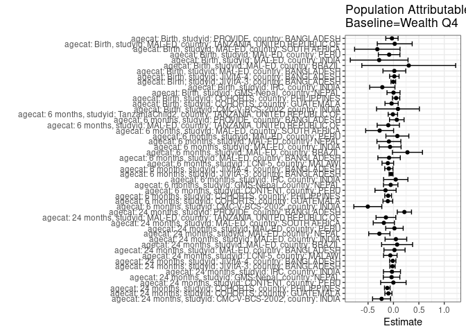

## Results Table

### Parameter: TSM

| agecat | studyid | country | intervention_level | baseline_level | estimate | ci_lower | ci_upper |
| --- | --- | --- | --- | --- | --- | --- | --- |
| Birth | CMC-V-BCS-2002 | INDIA | Wealth Q4 | NA | -0.5535247 | -1.1484235 | 0.0413741 |
| Birth | CMC-V-BCS-2002 | INDIA | Wealth Q1 | NA | -0.5368878 | -1.2276258 | 0.1538501 |
| Birth | CMC-V-BCS-2002 | INDIA | Wealth Q2 | NA | -0.6364531 | -1.1993264 | -0.0735798 |
| Birth | CMC-V-BCS-2002 | INDIA | Wealth Q3 | NA | -0.1041952 | -0.6323865 | 0.4239960 |
| Birth | COHORTS | GUATEMALA | Wealth Q4 | NA | -1.0200750 | -1.1925523 | -0.8475977 |
| Birth | COHORTS | GUATEMALA | Wealth Q1 | NA | -1.2356295 | -1.4388149 | -1.0324441 |
| Birth | COHORTS | GUATEMALA | Wealth Q2 | NA | -0.9955494 | -1.2192964 | -0.7718025 |
| Birth | COHORTS | GUATEMALA | Wealth Q3 | NA | -1.0308281 | -1.2344748 | -0.8271813 |
| Birth | COHORTS | PHILIPPINES | Wealth Q4 | NA | -0.7941445 | -0.8807830 | -0.7075060 |
| Birth | COHORTS | PHILIPPINES | Wealth Q1 | NA | -0.7790389 | -0.8793275 | -0.6787504 |
| Birth | COHORTS | PHILIPPINES | Wealth Q2 | NA | -0.6815634 | -0.7887700 | -0.5743569 |
| Birth | COHORTS | PHILIPPINES | Wealth Q3 | NA | -0.7244677 | -0.8036251 | -0.6453103 |
| Birth | GMS-Nepal | NEPAL | Wealth Q4 | NA | -1.1172942 | -1.2685975 | -0.9659908 |
| Birth | GMS-Nepal | NEPAL | Wealth Q1 | NA | -1.1116277 | -1.2641279 | -0.9591274 |
| Birth | GMS-Nepal | NEPAL | Wealth Q2 | NA | -1.1080673 | -1.2712277 | -0.9449068 |
| Birth | GMS-Nepal | NEPAL | Wealth Q3 | NA | -1.1383202 | -1.3116644 | -0.9649760 |
| Birth | IRC | INDIA | Wealth Q4 | NA | -0.7908563 | -1.0730423 | -0.5086702 |
| Birth | IRC | INDIA | Wealth Q1 | NA | -1.3265222 | -1.6344085 | -1.0186360 |
| Birth | IRC | INDIA | Wealth Q2 | NA | -0.9351725 | -1.2912324 | -0.5791126 |
| Birth | IRC | INDIA | Wealth Q3 | NA | -0.8460635 | -1.1702137 | -0.5219133 |
| Birth | JiVitA-3 | BANGLADESH | Wealth Q4 | NA | -0.7748179 | -0.8263404 | -0.7232953 |
| Birth | JiVitA-3 | BANGLADESH | Wealth Q1 | NA | -0.8228709 | -0.8643817 | -0.7813601 |
| Birth | JiVitA-3 | BANGLADESH | Wealth Q2 | NA | -0.7847947 | -0.8199713 | -0.7496180 |
| Birth | JiVitA-3 | BANGLADESH | Wealth Q3 | NA | -0.7777363 | -0.8104226 | -0.7450501 |
| Birth | JiVitA-4 | BANGLADESH | Wealth Q4 | NA | -0.7053595 | -0.8097666 | -0.6009525 |
| Birth | JiVitA-4 | BANGLADESH | Wealth Q1 | NA | -0.6584837 | -0.7731112 | -0.5438562 |
| Birth | JiVitA-4 | BANGLADESH | Wealth Q2 | NA | -0.7096859 | -0.8109772 | -0.6083945 |
| Birth | JiVitA-4 | BANGLADESH | Wealth Q3 | NA | -0.6990777 | -0.8272312 | -0.5709243 |
| Birth | MAL-ED | BANGLADESH | Wealth Q4 | NA | -0.9905978 | -1.2384110 | -0.7427847 |
| Birth | MAL-ED | BANGLADESH | Wealth Q1 | NA | -0.8204995 | -1.1395639 | -0.5014351 |

[output cut: 166 more lines]

### Parameter: E(Y)

| agecat | studyid | country | intervention_level | baseline_level | estimate | ci_lower | ci_upper |
| --- | --- | --- | --- | --- | --- | --- | --- |
| Birth | CMC-V-BCS-2002 | INDIA | NA | NA | -0.4648256 | -0.7643210 | -0.1653302 |
| Birth | COHORTS | GUATEMALA | NA | NA | -1.0572840 | -1.1606089 | -0.9539590 |
| Birth | COHORTS | PHILIPPINES | NA | NA | -0.7422912 | -0.7886598 | -0.6959226 |
| Birth | GMS-Nepal | NEPAL | NA | NA | -1.1164431 | -1.2040134 | -1.0288728 |
| Birth | IRC | INDIA | NA | NA | -1.0105831 | -1.1973019 | -0.8238643 |
| Birth | JiVitA-3 | BANGLADESH | NA | NA | -0.7777103 | -0.7967006 | -0.7587201 |
| Birth | JiVitA-4 | BANGLADESH | NA | NA | -0.6882498 | -0.7406539 | -0.6358456 |
| Birth | MAL-ED | BANGLADESH | NA | NA | -0.9728358 | -1.1217009 | -0.8239707 |
| Birth | MAL-ED | BRAZIL | NA | NA | 0.4643860 | 0.1360519 | 0.7927200 |
| Birth | MAL-ED | INDIA | NA | NA | -0.9441026 | -1.2397919 | -0.6484132 |
| Birth | MAL-ED | PERU | NA | NA | -0.0468095 | -0.1738806 | 0.0802616 |
| Birth | MAL-ED | SOUTH AFRICA | NA | NA | -0.1729474 | -0.4186222 | 0.0727275 |
| Birth | MAL-ED | TANZANIA, UNITED REPUBLIC OF | NA | NA | 0.7637500 | 0.5676177 | 0.9598823 |
| Birth | PROVIDE | BANGLADESH | NA | NA | -1.2984586 | -1.3752758 | -1.2216415 |
| 6 months | CMC-V-BCS-2002 | INDIA | NA | NA | -0.5026766 | -0.6536848 | -0.3516685 |
| 6 months | COHORTS | GUATEMALA | NA | NA | 0.1914471 | 0.1185005 | 0.2643936 |
| 6 months | COHORTS | PHILIPPINES | NA | NA | -0.2938433 | -0.3352064 | -0.2524802 |
| 6 months | CONTENT | PERU | NA | NA | 1.0644279 | 0.9468682 | 1.1819876 |
| 6 months | GMS-Nepal | NEPAL | NA | NA | -0.6038416 | -0.6899448 | -0.5177384 |
| 6 months | IRC | INDIA | NA | NA | -0.5989297 | -0.7344491 | -0.4634104 |
| 6 months | JiVitA-3 | BANGLADESH | NA | NA | -0.5932502 | -0.6127743 | -0.5737261 |
| 6 months | JiVitA-4 | BANGLADESH | NA | NA | -0.3901595 | -0.4274150 | -0.3529041 |
| 6 months | LCNI-5 | MALAWI | NA | NA | 0.4417647 | 0.3702742 | 0.5132552 |
| 6 months | MAL-ED | BANGLADESH | NA | NA | -0.1333333 | -0.2623761 | -0.0042906 |
| 6 months | MAL-ED | BRAZIL | NA | NA | 0.9720774 | 0.8078144 | 1.1363403 |
| 6 months | MAL-ED | INDIA | NA | NA | -0.7102872 | -0.8371659 | -0.5834085 |
| 6 months | MAL-ED | NEPAL | NA | NA | 0.1104308 | -0.0208643 | 0.2417259 |
| 6 months | MAL-ED | PERU | NA | NA | 1.0512099 | 0.9285617 | 1.1738581 |
| 6 months | MAL-ED | SOUTH AFRICA | NA | NA | 0.5404351 | 0.3867005 | 0.6941696 |
| 6 months | MAL-ED | TANZANIA, UNITED REPUBLIC OF | NA | NA | 0.5362213 | 0.4049390 | 0.6675036 |
| 6 months | PROVIDE | BANGLADESH | NA | NA | -0.1990907 | -0.2817968 | -0.1163845 |
| 6 months | TanzaniaChild2 | TANZANIA, UNITED REPUBLIC OF | NA | NA | 0.0801680 | 0.0273223 | 0.1330136 |
| 24 months | CMC-V-BCS-2002 | INDIA | NA | NA | -0.5571505 | -0.6585247 | -0.4557763 |
| 24 months | COHORTS | GUATEMALA | NA | NA | -0.2791396 | -0.3336899 | -0.2245893 |
| 24 months | COHORTS | PHILIPPINES | NA | NA | -0.6099592 | -0.6467541 | -0.5731643 |
| 24 months | CONTENT | PERU | NA | NA | 0.5902439 | 0.4560143 | 0.7244735 |
| 24 months | GMS-Nepal | NEPAL | NA | NA | -1.1363107 | -1.2252817 | -1.0473398 |
| 24 months | IRC | INDIA | NA | NA | -0.7458150 | -0.8368180 | -0.6548120 |
| 24 months | JiVitA-3 | BANGLADESH | NA | NA | -1.2973086 | -1.3206115 | -1.2740057 |
| 24 months | JiVitA-4 | BANGLADESH | NA | NA | -1.2231776 | -1.2550332 | -1.1913220 |
| 24 months | LCNI-5 | MALAWI | NA | NA | -0.0477867 | -0.1301103 | 0.0345368 |
| 24 months | MAL-ED | BANGLADESH | NA | NA | -0.8192925 | -0.9412667 | -0.6973182 |
| 24 months | MAL-ED | BRAZIL | NA | NA | 0.4626233 | 0.2567495 | 0.6684971 |
| 24 months | MAL-ED | INDIA | NA | NA | -0.9516520 | -1.0670654 | -0.8362385 |
| 24 months | MAL-ED | NEPAL | NA | NA | -0.3749123 | -0.4886073 | -0.2612173 |
| 24 months | MAL-ED | PERU | NA | NA | 0.1111982 | -0.0118399 | 0.2342362 |
| 24 months | MAL-ED | SOUTH AFRICA | NA | NA | 0.4090301 | 0.2879441 | 0.5301161 |
| 24 months | MAL-ED | TANZANIA, UNITED REPUBLIC OF | NA | NA | 0.0547975 | -0.0703378 | 0.1799328 |
| 24 months | PROVIDE | BANGLADESH | NA | NA | -0.8928670 | -0.9755153 | -0.8102187 |

### Parameter: ATE

| agecat | studyid | country | intervention_level | baseline_level | estimate | ci_lower | ci_upper |
| --- | --- | --- | --- | --- | --- | --- | --- |
| Birth | CMC-V-BCS-2002 | INDIA | Wealth Q4 | Wealth Q4 | 0.0000000 | 0.0000000 | 0.0000000 |
| Birth | CMC-V-BCS-2002 | INDIA | Wealth Q1 | Wealth Q4 | 0.0166369 | -0.8905716 | 0.9238454 |
| Birth | CMC-V-BCS-2002 | INDIA | Wealth Q2 | Wealth Q4 | -0.0829284 | -0.9031203 | 0.7372635 |
| Birth | CMC-V-BCS-2002 | INDIA | Wealth Q3 | Wealth Q4 | 0.4493295 | -0.3449467 | 1.2436057 |
| Birth | COHORTS | GUATEMALA | Wealth Q4 | Wealth Q4 | 0.0000000 | 0.0000000 | 0.0000000 |
| Birth | COHORTS | GUATEMALA | Wealth Q1 | Wealth Q4 | -0.2155545 | -0.4752609 | 0.0441520 |
| Birth | COHORTS | GUATEMALA | Wealth Q2 | Wealth Q4 | 0.0245256 | -0.2509509 | 0.3000020 |
| Birth | COHORTS | GUATEMALA | Wealth Q3 | Wealth Q4 | -0.0107531 | -0.2696199 | 0.2481138 |
| Birth | COHORTS | PHILIPPINES | Wealth Q4 | Wealth Q4 | 0.0000000 | 0.0000000 | 0.0000000 |
| Birth | COHORTS | PHILIPPINES | Wealth Q1 | Wealth Q4 | 0.0151056 | -0.1153862 | 0.1455973 |
| Birth | COHORTS | PHILIPPINES | Wealth Q2 | Wealth Q4 | 0.1125810 | -0.0234013 | 0.2485634 |
| Birth | COHORTS | PHILIPPINES | Wealth Q3 | Wealth Q4 | 0.0696768 | -0.0454439 | 0.1847975 |
| Birth | GMS-Nepal | NEPAL | Wealth Q4 | Wealth Q4 | 0.0000000 | 0.0000000 | 0.0000000 |
| Birth | GMS-Nepal | NEPAL | Wealth Q1 | Wealth Q4 | 0.0056665 | -0.2004317 | 0.2117647 |
| Birth | GMS-Nepal | NEPAL | Wealth Q2 | Wealth Q4 | 0.0092269 | -0.2047264 | 0.2231801 |
| Birth | GMS-Nepal | NEPAL | Wealth Q3 | Wealth Q4 | -0.0210261 | -0.2425949 | 0.2005428 |
| Birth | IRC | INDIA | Wealth Q4 | Wealth Q4 | 0.0000000 | 0.0000000 | 0.0000000 |
| Birth | IRC | INDIA | Wealth Q1 | Wealth Q4 | -0.5356659 | -0.9294350 | -0.1418969 |
| Birth | IRC | INDIA | Wealth Q2 | Wealth Q4 | -0.1443162 | -0.5729964 | 0.2843639 |
| Birth | IRC | INDIA | Wealth Q3 | Wealth Q4 | -0.0552072 | -0.4569645 | 0.3465500 |
| Birth | JiVitA-3 | BANGLADESH | Wealth Q4 | Wealth Q4 | 0.0000000 | 0.0000000 | 0.0000000 |
| Birth | JiVitA-3 | BANGLADESH | Wealth Q1 | Wealth Q4 | -0.0480531 | -0.1096323 | 0.0135262 |
| Birth | JiVitA-3 | BANGLADESH | Wealth Q2 | Wealth Q4 | -0.0099768 | -0.0706112 | 0.0506576 |
| Birth | JiVitA-3 | BANGLADESH | Wealth Q3 | Wealth Q4 | -0.0029185 | -0.0607198 | 0.0548828 |
| Birth | JiVitA-4 | BANGLADESH | Wealth Q4 | Wealth Q4 | 0.0000000 | 0.0000000 | 0.0000000 |
| Birth | JiVitA-4 | BANGLADESH | Wealth Q1 | Wealth Q4 | 0.0468758 | -0.1055166 | 0.1992682 |
| Birth | JiVitA-4 | BANGLADESH | Wealth Q2 | Wealth Q4 | -0.0043263 | -0.1491829 | 0.1405302 |
| Birth | JiVitA-4 | BANGLADESH | Wealth Q3 | Wealth Q4 | 0.0062818 | -0.1572938 | 0.1698574 |
| Birth | MAL-ED | BANGLADESH | Wealth Q4 | Wealth Q4 | 0.0000000 | 0.0000000 | 0.0000000 |
| Birth | MAL-ED | BANGLADESH | Wealth Q1 | Wealth Q4 | 0.1700983 | -0.2346314 | 0.5748281 |

[output cut: 166 more lines]

### Parameter: PAR

| agecat | studyid | country | intervention_level | baseline_level | estimate | ci_lower | ci_upper |
| --- | --- | --- | --- | --- | --- | --- | --- |
| Birth | CMC-V-BCS-2002 | INDIA | Wealth Q4 | NA | 0.0886992 | -0.3330446 | 0.5104429 |
| Birth | COHORTS | GUATEMALA | Wealth Q4 | NA | -0.0372089 | -0.1668918 | 0.0924740 |
| Birth | COHORTS | PHILIPPINES | Wealth Q4 | NA | 0.0518532 | -0.0209314 | 0.1246379 |
| Birth | GMS-Nepal | NEPAL | Wealth Q4 | NA | 0.0008511 | -0.1273741 | 0.1290763 |
| Birth | IRC | INDIA | Wealth Q4 | NA | -0.2197268 | -0.4686293 | 0.0291757 |
| Birth | JiVitA-3 | BANGLADESH | Wealth Q4 | NA | -0.0028925 | -0.0491148 | 0.0433298 |
| Birth | JiVitA-4 | BANGLADESH | Wealth Q4 | NA | 0.0171097 | -0.0758351 | 0.1100546 |
| Birth | MAL-ED | BANGLADESH | Wealth Q4 | NA | 0.0177620 | -0.2069767 | 0.2425007 |
| Birth | MAL-ED | BRAZIL | Wealth Q4 | NA | 0.3009674 | -0.6225167 | 1.2244515 |
| Birth | MAL-ED | INDIA | Wealth Q4 | NA | -0.2816026 | -0.8500282 | 0.2868230 |
| Birth | MAL-ED | PERU | Wealth Q4 | NA | -0.0851447 | -0.2975835 | 0.1272940 |
| Birth | MAL-ED | SOUTH AFRICA | Wealth Q4 | NA | -0.3179703 | -0.7651818 | 0.1292413 |
| Birth | MAL-ED | TANZANIA, UNITED REPUBLIC OF | Wealth Q4 | NA | 0.0249169 | -0.3187987 | 0.3686325 |
| Birth | PROVIDE | BANGLADESH | Wealth Q4 | NA | -0.0301062 | -0.1511512 | 0.0909389 |
| 6 months | CMC-V-BCS-2002 | INDIA | Wealth Q4 | NA | -0.5048355 | -0.7803386 | -0.2293323 |
| 6 months | COHORTS | GUATEMALA | Wealth Q4 | NA | -0.1108460 | -0.2064586 | -0.0152334 |
| 6 months | COHORTS | PHILIPPINES | Wealth Q4 | NA | -0.1044163 | -0.1709091 | -0.0379234 |
| 6 months | CONTENT | PERU | Wealth Q4 | NA | -0.1560404 | -0.3641450 | 0.0520642 |
| 6 months | GMS-Nepal | NEPAL | Wealth Q4 | NA | -0.0545929 | -0.1966473 | 0.0874615 |
| 6 months | IRC | INDIA | Wealth Q4 | NA | 0.0449616 | -0.1940958 | 0.2840190 |
| 6 months | JiVitA-3 | BANGLADESH | Wealth Q4 | NA | -0.0480225 | -0.0868735 | -0.0091715 |
| 6 months | JiVitA-4 | BANGLADESH | Wealth Q4 | NA | -0.0909837 | -0.1716282 | -0.0103392 |
| 6 months | LCNI-5 | MALAWI | Wealth Q4 | NA | -0.1111537 | -0.2252394 | 0.0029319 |
| 6 months | MAL-ED | BANGLADESH | Wealth Q4 | NA | -0.0860945 | -0.3068845 | 0.1346955 |
| 6 months | MAL-ED | BRAZIL | Wealth Q4 | NA | 0.2752169 | -0.0206954 | 0.5711292 |
| 6 months | MAL-ED | INDIA | Wealth Q4 | NA | -0.0668170 | -0.2835564 | 0.1499225 |
| 6 months | MAL-ED | NEPAL | Wealth Q4 | NA | -0.0899007 | -0.3252707 | 0.1454693 |
| 6 months | MAL-ED | PERU | Wealth Q4 | NA | 0.0767192 | -0.1491482 | 0.3025867 |
| 6 months | MAL-ED | SOUTH AFRICA | Wealth Q4 | NA | -0.2720628 | -0.5469630 | 0.0028374 |
| 6 months | MAL-ED | TANZANIA, UNITED REPUBLIC OF | Wealth Q4 | NA | -0.1021965 | -0.3211917 | 0.1167987 |
| 6 months | PROVIDE | BANGLADESH | Wealth Q4 | NA | 0.0653587 | -0.0779331 | 0.2086506 |
| 6 months | TanzaniaChild2 | TANZANIA, UNITED REPUBLIC OF | Wealth Q4 | NA | -0.0113959 | -0.1037956 | 0.0810039 |
| 24 months | CMC-V-BCS-2002 | INDIA | Wealth Q4 | NA | -0.2336397 | -0.4108776 | -0.0564017 |
| 24 months | COHORTS | GUATEMALA | Wealth Q4 | NA | -0.0993279 | -0.1686859 | -0.0299699 |
| 24 months | COHORTS | PHILIPPINES | Wealth Q4 | NA | -0.1213901 | -0.1765875 | -0.0661926 |
| 24 months | CONTENT | PERU | Wealth Q4 | NA | -0.0016054 | -0.2518170 | 0.2486063 |
| 24 months | GMS-Nepal | NEPAL | Wealth Q4 | NA | -0.0373312 | -0.2002892 | 0.1256268 |
| 24 months | IRC | INDIA | Wealth Q4 | NA | -0.0294976 | -0.1970697 | 0.1380745 |
| 24 months | JiVitA-3 | BANGLADESH | Wealth Q4 | NA | -0.0196605 | -0.0722505 | 0.0329295 |
| 24 months | JiVitA-4 | BANGLADESH | Wealth Q4 | NA | -0.0141409 | -0.0759121 | 0.0476304 |
| 24 months | LCNI-5 | MALAWI | Wealth Q4 | NA | -0.0617889 | -0.1946964 | 0.0711186 |
| 24 months | MAL-ED | BANGLADESH | Wealth Q4 | NA | 0.0203377 | -0.1876595 | 0.2283349 |
| 24 months | MAL-ED | BRAZIL | Wealth Q4 | NA | 0.0716635 | -0.2331933 | 0.3765203 |
| 24 months | MAL-ED | INDIA | Wealth Q4 | NA | 0.0478887 | -0.1652452 | 0.2610226 |
| 24 months | MAL-ED | NEPAL | Wealth Q4 | NA | -0.2779812 | -0.4867192 | -0.0692431 |
| 24 months | MAL-ED | PERU | Wealth Q4 | NA | 0.0193704 | -0.1525380 | 0.1912787 |
| 24 months | MAL-ED | SOUTH AFRICA | Wealth Q4 | NA | -0.1897753 | -0.3984223 | 0.0188716 |
| 24 months | MAL-ED | TANZANIA, UNITED REPUBLIC OF | Wealth Q4 | NA | -0.1484673 | -0.3428699 | 0.0459354 |
| 24 months | PROVIDE | BANGLADESH | Wealth Q4 | NA | 0.2149644 | 0.0748801 | 0.3550488 |